# NYC Flights

Coach Skufca

2022-09-09

Class play with NYC flights data.

Experiment 3 includes summarizing, looking to match another report.

## Load Packages

```r
library(nycflights13)
library(tidyverse)
library(here)
library(janitor)
```

## Load flight data

```r
df1=flights
```

## Class work

In class, we first looked at flights to MIAMI, creating a barplot.

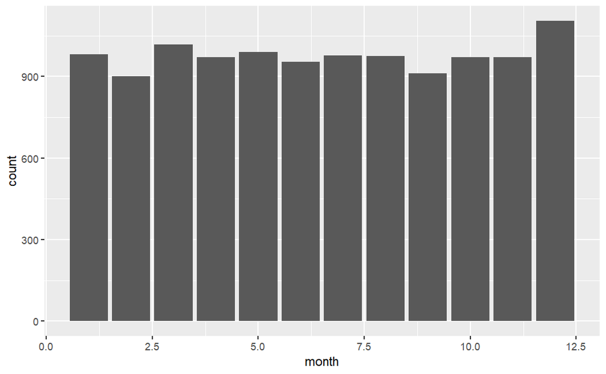

```r
df6=df1 %>%
  filter(dest=="MIA")


df6 %>% ggplot(aes(month)) + geom_bar()
```

Analyzing the graph above we note:

- December has the most flights, perhaps due to holiday.
- Feb is low, perhaps due to fewer days in Feb.
- Flight numbers seem to correlate with days in the month.

### Other destinations

We are interested in whether the Miami pattern is replicated at other airports. We consider six major airport:

- LAX - Los Angeles
- SAN - San Diego
- SFO - San Francisco
- ATL - Atlanta
- ORD - Chicago O’hare
- MIA - Miami

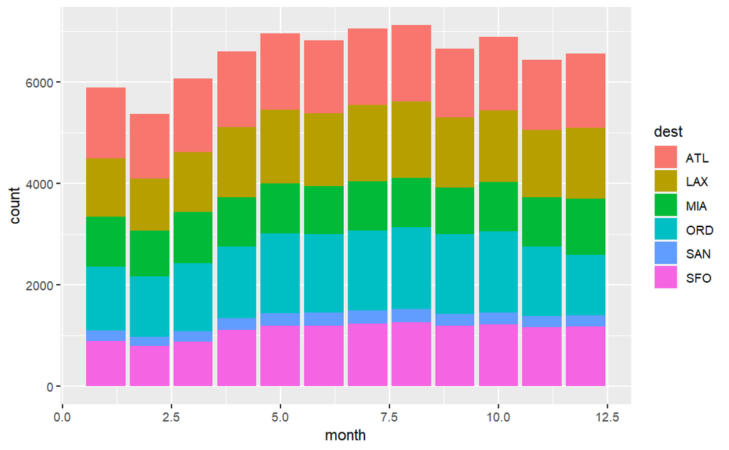

```r
df7=df1 %>%
  filter(dest %in% c("LAX","SAN","SFO","ATL","ORD","MIA"))


df7 %>% ggplot(aes(x=month,fill=dest)) + geom_bar()
```

The stacked bar chart looks pretty, but we can’t really compare the pattern across locations. We will use *faceting* to separate the plots.

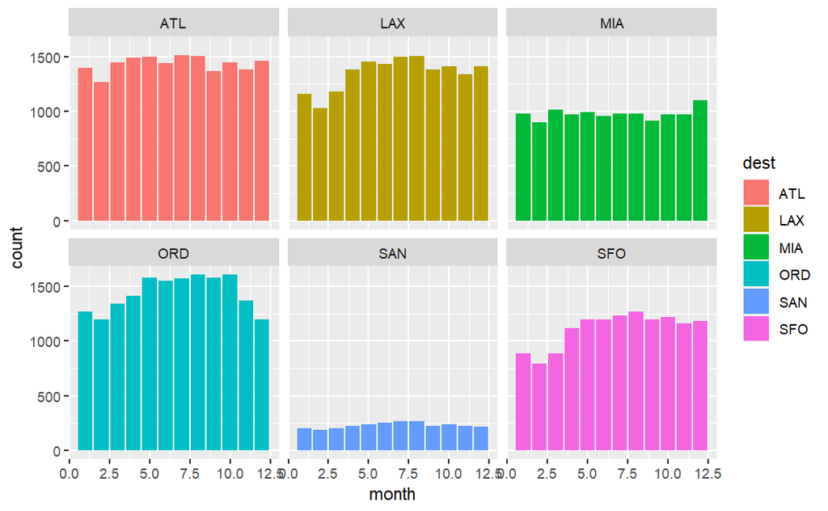

```r
df7 %>% ggplot(aes(month,fill=dest)) + geom_bar()+facet_wrap(~dest)
```

Observation from above graph:

- San Diego is much smaller than the others.
- MIA is *unusually* flat.
- ORD is summer intensive (more traffic over summer)
- ORD, LAX, SFO patterns similar: low in winter, high in summer.
- ATL is flat, perhaps it’s a hub.
- Feb is low (fewer days) and winter.

# Homework

## Another source of data - Bureau of Transportation

We will access a much larger data source, with WAY more data, should we want. But … we first focus on a particular download goal to get some data which is similar to what we were using.

## YOUR ACTION REQUIRED

Go to website https://www.transtats.bts.gov/DL_SelectFields.aspx?gnoyr_VQ=FIM&QO_fu146_anzr=Nv4%20Pn44vr45 . This dataset allows access to information on domestic flight and domestic carriers, with monthly summary data.

I want you to download the data for 2019, selecting all fields for download.

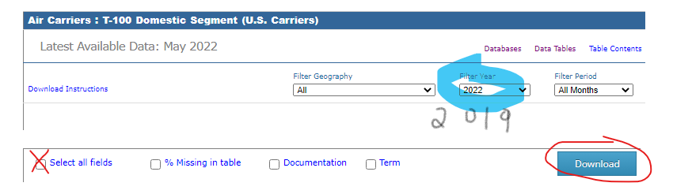

> Save the download to your data_raw directory. It will be a zipfile, but that will be OK. Don’t change the name of the zipfile.

## Load the BOT data

We take advantage of the `here` package to get the path to the file that we stored.

Load that data into dataframe called `df2019` using the read_csv command. Note that you do not need to unzip the file.

**NOTE** I use `clean_names` from the janitor package to get names formatted in a consistent and useable way.

```r
thisfile=here("data_raw","DL_SelectFields.zip")

df2019=read_csv(thisfile) %>% clean_names()
```

## Subsetting to data of interest

Let’s focus on flights from La Guardia (airport “LGA”) and eliminate cargo flights by requiring at leat 1 passenger.

Call the resultant dataframe `df9`.

```r
df9=df2019 %>% filter(passengers>0,origin=="LGA")
```

We create a barchart as we have done before:

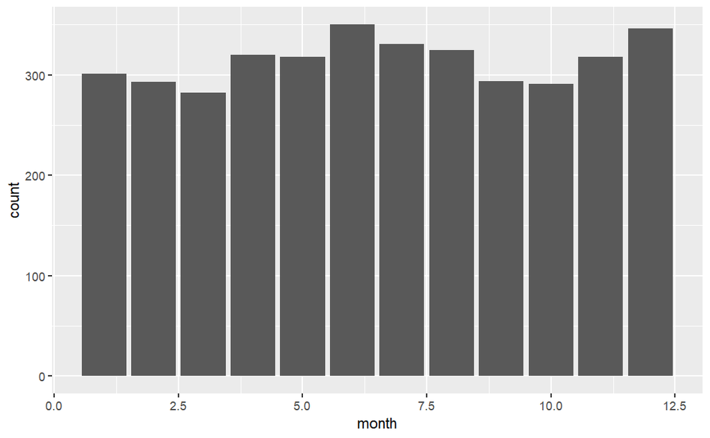

```r
df9 %>% ggplot(aes(month)) + geom_bar()
```

By default, `geom_bar` is counting the number of rows, where we asked it to visualize the count by `month`.

** Take a look at the dataset and discover why counting rows is not going to give us a count of flights. **

The visualization we want is:

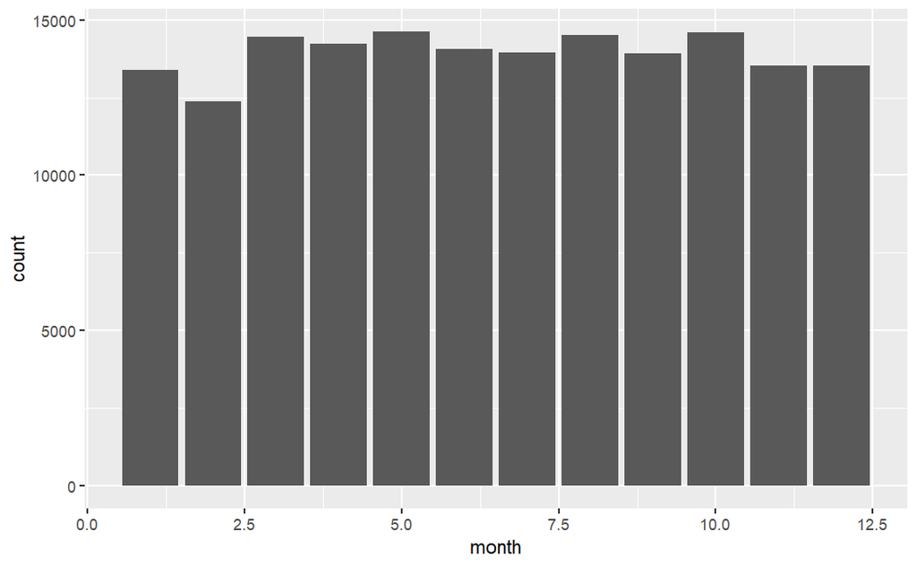

```r
df9 %>% ggplot(aes(month)) + geom_bar(aes(weight=departures_performed))
```

Make some observations about this plot.

### A new visualization

Can you make a boxplot where the bar height is based on the number of passengers riding each month.

### Just because you can

Here is pretty, but not so useful plot.

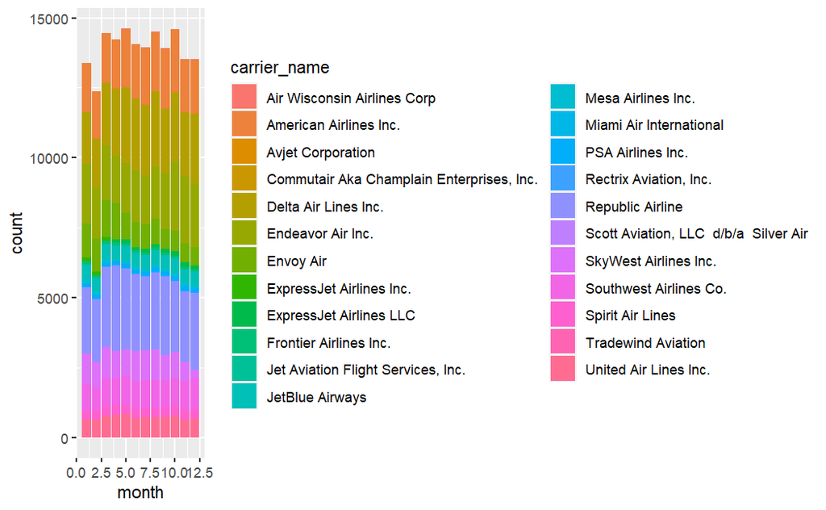

```r
df9 %>% ggplot(aes(month,fill=carrier_name)) + geom_bar(aes(weight=departures_performed))
```

## Arrivals and departures from LGA

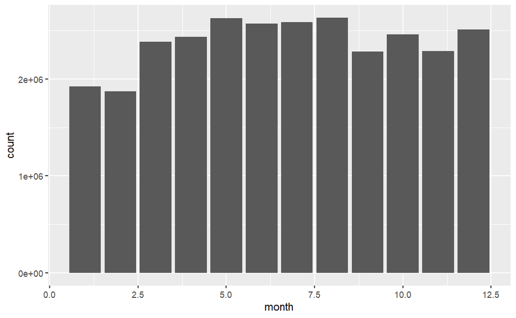

```r
df10=df2019 %>% filter(passengers>0,origin=="LGA" | dest=="LGA")

df10 %>% ggplot(aes(month)) + geom_bar(aes(weight=passengers))
```

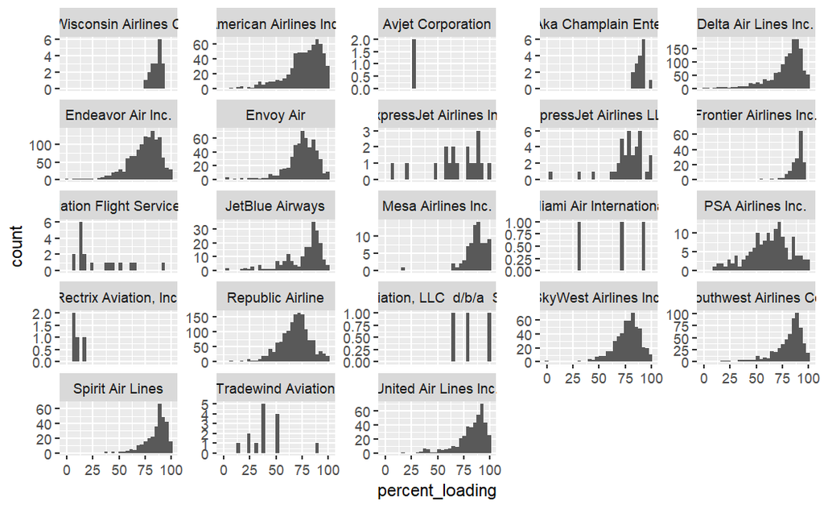

```r
df11=df10 %>% select(month,passengers,seats, carrier_name, dest, origin)

df12=df10 %>% select(1:5, month, contains("id") )

df13=df11 %>% mutate(percent_loading = passengers/seats*100)

df13 %>% ggplot(aes(percent_loading)) +
  geom_histogram()+facet_wrap(~carrier_name,scales="free_y")
```

### Summarize data

```r
df15=df2019 %>% filter(passengers>0,origin=="LGA" | dest=="LGA") %>%
  group_by(month,carrier_name) %>%
  summarise(total_pass=sum(passengers),  num_flights=sum(departures_performed)) %>%
  mutate(average_pass_per_flight=total_pass/num_flights)
```

[output not shown]

```r
df15
```

| month | carrier_name | total_pass | num_flights | average_pass_per_flight |
| --- | --- | --- | --- | --- |
| 1 | American Airlines Inc. | 384843 | 3486 | 110.396730 |
| 1 | Delta Air Lines Inc. | 435492 | 3719 | 117.099220 |
| 1 | Endeavor Air Inc. | 167789 | 4230 | 39.666430 |
| 1 | Envoy Air | 62284 | 2445 | 25.474029 |
| 1 | ExpressJet Airlines Inc. | 8758 | 296 | 29.587838 |
| 1 | Frontier Airlines Inc. | 29813 | 182 | 163.807692 |
| 1 | Jet Aviation Flight Services, Inc. | 14 | 5 | 2.800000 |
| 1 | JetBlue Airways | 100093 | 1002 | 99.893214 |
| 1 | Mesa Airlines Inc. | 18365 | 334 | 54.985030 |
| 1 | PSA Airlines Inc. | 5918 | 286 | 20.692308 |

[output cut: 197 more lines]

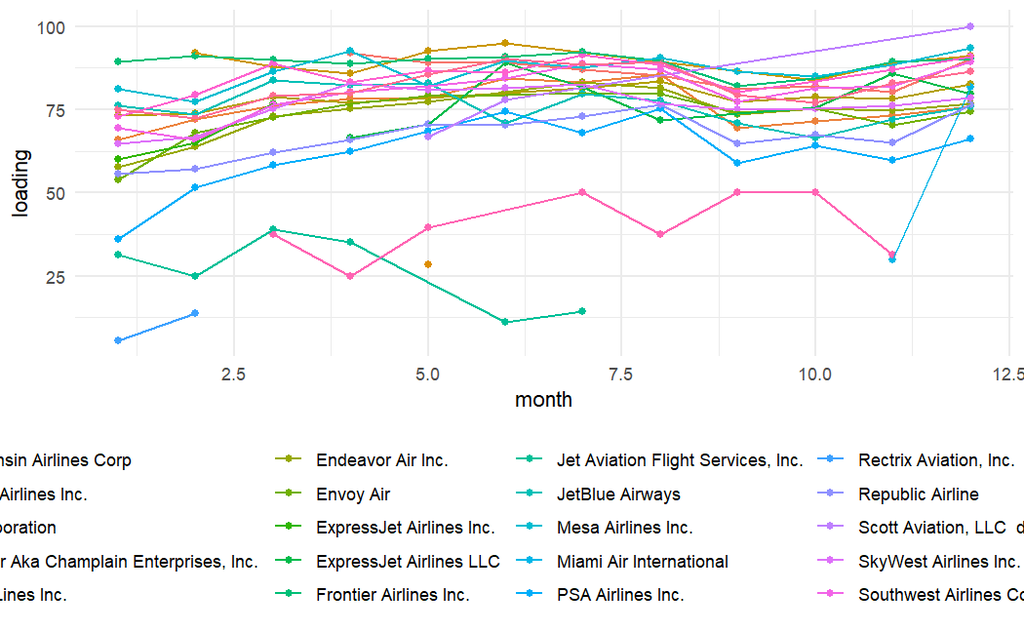

```r
df16 %>% ggplot(aes(x=month,y=loading,color=carrier_name))+
  geom_point()+
  theme_minimal()+geom_line()+
  theme(legend.position="bottom")
```

### cargo questions - which airport

```r
df17=df2019 %>% filter(origin_city_name=="New York, NY" ) %>%
  group_by(month,origin) %>%
  summarise(freight=sum(freight,na.rm = FALSE),passengers=sum(passengers),n=n())
df17
```

| month | origin | freight | passengers | n |
| --- | --- | --- | --- | --- |
| 1 | JFK | 22745750 | 1069097 | 369 |
| 1 | JRA | 0 | 3 | 1 |
| 1 | LGA | 445620 | 963406 | 303 |
| 1 | TSS | 0 | 7 | 1 |
| 2 | JFK | 21614836 | 997833 | 326 |
| 2 | JRA | 0 | 10 | 2 |
| 2 | LGA | 400569 | 935384 | 295 |
| 2 | TSS | 0 | 0 | 1 |
| 3 | JFK | 26004087 | 1220625 | 327 |
| 3 | JRA | 0 | 8 | 2 |

[output cut: 40 more lines]